Back to Index

# Decision Trees in Data Science

## Overview

Decision Trees are a type of supervised learning algorithm that are used for both classification and regression tasks. They are called 'trees' because they model decisions as a series of branching paths, resembling a tree structure.

## Key Characteristics

- **Interpretability**: Easy to understand and interpret, often visualized graphically.
- **Binary Splits**: Typically split data into two branches at each decision node.
- **Overfitting**: Prone to overfitting, especially with complex trees.
- **Handling Different Types of Data**: Can handle both numerical and categorical data.
- **Non-Linear Relationships**: Good at capturing non-linear relationships.
- **Piecewise Linear Approach**: Decision trees handle non-linear relationships by creating piecewise linear boundaries. Even though each individual split is linear and orthogonal to a feature axis, the combination of many such splits can approximate a non-linear relationship.
- **Stepwise Segmentation**: By segmenting the feature space into smaller and smaller regions (each aligned with feature axes), decision trees can capture complex patterns in the data.
- **Hierarchical Structure**: The tree structure allows for modeling interactions between variables in a hierarchical manner, which can mimic certain types of non-linear relationships.

## Algorithm

1. **Node Creation**: Begins with a root node and includes all data.
2. **Best Split Selection**: At each node, algorithm selects the best split based on a criterion (e.g., Gini impurity, entropy for classification, variance reduction for regression).
3. **Repeating Process**: Continues splitting until certain conditions are met (e.g., maximum depth, minimum number of samples at a node).
4. **Pruning**: Optional step to remove parts of the tree that provide little power to classify instances.
- **Pros**:
  - **Simple to Understand and Interpret**: Decision trees are highly interpretable, with a clear, visual representation of decision-making steps.
  - **Minimal Data Preprocessing Required**: They handle both numerical and categorical data and often require less preprocessing (e.g., no need for scaling).
  - **Feature Selection**: Inherently perform feature selection, indicating the most informative features for classification or regression.
  - **Non-Parametric Nature**: They do not assume a particular distribution of the data, making them flexible in handling various types of datasets.
  - **Capability to Model Non-Linear Relationships**: Through hierarchical and segmented structure, they can approximate complex, non-linear relationships.
- **Cons**:
  - **Prone to Overfitting**: Especially in cases of a large number of features or deep trees, they can overfit the training data, leading to poor generalization.
  - **Sensitivity to Variations in Data**: Small changes in the training data can lead to significantly different tree structures.
  - **Axis-Aligned Decision Boundaries**: Splits are orthogonal to feature axes, which may not always capture the most natural divisions in the data.
  - **Limited in Handling Continuous Variables**: While they can process continuous variables, they may not be as effective compared to other models, particularly when predicting continuous outcomes.
  - **Scalability**: Large datasets can lead to very complex trees that are computationally expensive to train.
- **Orthogonal to Feature Axes**: The decision boundaries made by a decision tree are perpendicular to the feature axes. This means that the splits the tree makes are along the values of a specific feature.
- **Implication**: Such splits divide the feature space into regions that are aligned along the axes of the features.
- **Example**: If a decision tree splits on a feature 'X', the boundary will be a line (in 2D space) or a plane (in 3D space) that is orthogonal to the 'X' axis at a specific value of 'X'.
- **Limitation**: This approach limits the flexibility of the model in capturing more complex, non-linear relationships, as all splits are axis-aligned.

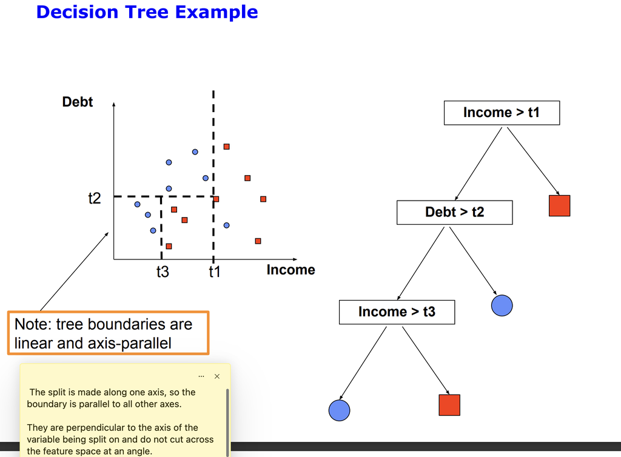

## Applications

- **Business Management**: Decision-making in strategic planning.
- **Healthcare**: Diagnosing medical conditions.
- **Finance**: Credit scoring and risk assessment.
- **Manufacturing**: Quality control and defect detection.
- **Marketing**: Customer segmentation and targeting.

## Types of Decision Tree algorithms

### Decision Tree Types Based on Output

#### Classification Trees

- Purpose: Classify categorical target variables.
- Example Algorithms: ID3, C4.5, CHAID.

#### Regression Trees

- Purpose: Predict continuous target variables.
- Example Algorithm: CART.

### Decision Tree Variants Based on Structure

#### Binary Decision Trees

- Structure: Each node splits into exactly two branches.
- Common in: CART, some implementations of ID3 and C4.5.

#### Multi-way Decision Trees

- Structure: Nodes can split into more than two branches.
- Common in: CHAID, some implementations of C4.5.

### Specific Decision Tree Algorithms

#### CART (Classification and Regression Trees)

- Versatile: Used for both classification and regression.
- Typically Binary: Often constructs binary trees.

CART notes

#### ID3 (Iterative Dichotomiser 3)

- Focus: Classification with categorical data.
- Tree Structure: Can vary between binary and non-binary.

#### C4.5

- Extension of ID3: Handles both continuous and discrete attributes.
- Flexible Structure: Capable of binary and non-binary splits.

#### CHAID (Chi-squared Automatic Interaction Detection)

- Specialization: Classification, known for multi-level splits.
- Tree Structure: Non-binary, handling complex data patterns.